# Bayesian exponential random graph modelling of KWL Burial network

Author One

Author Two

07 April, 2020

Abstract

# 1 Introduction

Burials provide valuable information about social structures that reflect not only the personal life and status of the deceased, but also the expressions of their descendants, from which we are able to detect the social differences that can relate to social inequality and complexity (Ehrhardt, 2009; Gamble and Zepeda, 2002; Janes, 2013; Johansen and Bauer, 2015). Mortuary practices such as burial forms, grave goods, and related ritual practices could represent the social relations between individuals and allow us to infer social structures, for examples, grave goods usually relate to social practices of trade, exchange, and gifting (Coward, 2013, p. 252). One way to study the relationships between individual is social network analysis (SNA), which can visualize, quantify, and statistically test hypotheses about the relationships to understand network structure and its effects on every part within the network (Freeman, 2004; Salvini, 2010). A social network contains a set of actors and a set of relationships connecting these actors, which could be groups, organizations or persons. Their relationships are flows of resources that reflect relations of control, dependence, and cooperation. In other words, actors are viewed as “nodes” in a wider network, in which nodes are connected by multiple relationships, or “edges”, to other nodes (Coward, 2013; Mizoguchi, 2013; Potgieter et al., 2008).

Exponential Random Graph Models (ERGMs) are an important family of statistical model for network analysis to describe the formation of ties in a network. In traditional statistical model for network, a dyad, the pair of nodes, is measured by the presence of a tie according to the attributes of the nodes or ties, where each predictor variable for forming a tie is measured separately. In contrast to traditional model where variables not interacting with each other, ERGMs assumes the formation of a tie is influenced by the presence or absence of other ties or attributes of nodes and ties (Robins et al. 2007). In a network using ERGMs, predictor variables, called “network statistics”, are direct functions of the ties themselves that the probability of occurrence of the configuration of ties can be hypothesized (Morris et al., 2008). This approach enables networks to be constructed in a variety of assumption and contexts to model social network in the past using archaeological data (Amati et al., 2019). However, ERGMs are difficult to compute because their normalizing constant depending on model parameters is intractable. A Bayesian framework allows for parameter inference using Markov chain Monte Carlo (MCMC) strategies which avoid the need for computationally intensive calculations of the normalizing constants (Caimo and Friel, 2011).

Using the R language, we use Bayesian SNA to study burials from Kiwulan, an Iron Age site in northeast Taiwan. We view individual burials as actors or nodes in the social network with ties drawn between burials when the presence of the same variables that can represent the same “community” or social group. We test hypotheses about the distribution of influence in the network to identify network or corporate mode conditions. We ask the questions: 1. Do the observed burial data indicate a more clustered network than a distribution of random networks with similar qualities? 2. Whether European colonial activities in 17 century Taiwan resulted in the emergence of social inequality in an indigenous society can be detected by burials networks. 3. How the relations among burials may affect the quantity of burial goods? We expect the network to present a higher degree of clustering (e.g. the number of completed triangles in the network) in the European contact period that might hint at social heterogeneity during this period. This study helps to expand the use of burials in understanding the indirect effects of a colonial presence on indigenous groups. A Bayesian approach enables the efficient quantification for uncertainty, parametrization, and model evaluation of social network metrics.

# 2 Archaeological background

The burial data we analyzed in this paper are collected from the upper component of Kiwulan site, an Iron Age settlement site (AD1350-AD1950) located in northeastern Taiwan which experienced the European colonial impacts in the 17th century and the large wave of Chinese immigrants in the 19th century. The excavation revealed abundant pottery sherds, imported ceramics and stonewares, wooden artifacts, stone tools, metal artifacts, imported glass beads and agates beads, and pipes (Chen, 2007). In addition to these artifacts, 90 burials, hundreds of middens, storage pits, and postholes with in-situ posts were also excavated. The burials were mostly located in the AD section, which is the largest open area at Kiwulan site that provides continuous stratigraphic sections suitable for comparison. Those burials are oriented in an east-west direction located on the north side of the house structures indicated by postholes and in-situ wooden posts. Previous research indicates the presence of economic inequality between burials, but there is debate about whether these represent an egalitarian or stratified society (Cheng, 2008; Hsieh, 2012). Cheng (2008) interprets the unequal distribution of prestige materials, such as the golden beads, between burials, as evidence for hierarchy. However, Hsieh (2012) suggests a relatively egalitarian form from the comparative analysis of frequency and proportion of burial goods. She finds that the rich burials were usually associated with elders, which might indicate achieved, rather than inherited, status. The use of prestige goods in burials might be traced back before the European arrival according to historical records from Spanish and Chinese [Borao Mateo (2009); Li and Wu 2006). Analysing burial data will give an insight into the social reactions of Kiwulan residents and provide a way to examine and explain the changes in social inequality at Kiwulan before and after European contact.

Burials were assigned to the pre-European period, European and post-European period, and Chinese period for network comparison. Since the sedimentary characteristics show vertical and lateral continuity cross units of AD section, depth is used as the first criterion for burial chronology. The chronology is then evaluated by the burials with light grey glazed jars, also called An-ping jars produced most likely in China and circulated in Southeast Asia from the late 16th to 18th century but are often found at sites with the European occupation in the early 17th century in Taiwan (Berrocal et al., 2018; Hsieh, 1995; Ketel, 2011). In addition to the diagnostic porcelain, three radiocarbon dates of charcoal associated with three different burials are used as another evidence to evaluate the chronology (Chen, 2007). Some burials that were heavily disturbed by modern construction are excluded to avoid misinterpreting from incomplete data.

The archaeological sites in northeastern Taiwan show some evidence of accumulation of imported prestige goods in burials (Chen 2005; Cheng 2008), which might indicate the pursuit of prestige or wealth. In addition to prestige, European colonial powers could have provided military support to indigenous allies. For example, Voss’s (2005) study of a colonial outpost in California shows that colonial residents have different identities and higher social status than other local indigenous people. A general model to summarize these case studies might be that the support of a colonial power combined with high local values for imported goods, might lead to competition among individuals. In this study, I will use this model of competition to explain the changes in social inequality at Kiwulan before and after European contact.

Based on the quantity of grave goods among burials, we can reconstruct social networks from the distribution of prestige goods, including imported ceramic and beads based on the principle that prestige materials usually relate to social status. We build network where burials represent actors (nodes in the network) linked by sharing the same prestige goods.

## 2.1 Bayesian inference for Exponential Random Graph Models

Bayesian approach to ERGMs is an efficient computational tool for social network analysis because it incorporates prior information about the network effects into the model and offers uncertainty quantification by evaluating the posterior distribution of the parameters associated with the network effects (Caimo and Lomi, 2015; Nemmers et al., 2019). This provides better estimations for complex social network models with heterogeneous data (Caimo et al., 2017).

some concepts: - endogenous statistics that ties are modelled based on the existence of other ties - exogenous statistics that ties are formed according to monadic or dyadic node attributes

# 3 Methods

We use burial data from different time periods at Kiwulan and consider the effects of both exogenous and endogenous factors that could provide meaningful explanation of the characteristics of burial network and tendency of burials correlate with each other. To be specific, our purpose is to understand the underlying mechanisms of the network structures and how the relationship influence on the pattern of accumulation of wealth during different foreign contact periods. We focus on connectivity, clusters, centralization, and homophily among those burials that could reflect the social relations between individuals guided by social structures.Previous studies have shown that there are some evidence of social inequality observed from Kiwulan but the degree over time and causes remain unclear. To answer our question for the shifts in social inequality to a more wealth differentiation during and after the arrival of the foreign presences, we hypothesize:

• Hypothesis 1: There are significant reciprocal structure effects in burial network before the contact • Hypothesis 2: There are significant transitivity structure effects in burial network after the contact • Hypothesis 3: There are significant popularity structure effects in in burial network after the contact

The computational processes in this paper were performed by the ergm package for simulation and model specification and then bergm package using R programming (Caimo and Friel, 2014; Hunter et al., 2008; Morris et al., 2008). We set the number of chains to eight. For each chain, the number of burn-in iterations is 200 and the number of iterations after the burn-in is 2000. We set the number of iterations used to simulate a network y′ at each iteration to 10000. The models are assessed by goodness-of-fit (GOF) diagnostics in the Bayesian framework, where the observed network is compared with a set of networks simulated from the estimated posterior distribution of the parameters of the model (Caimo and Friel, 2011; Caimo et al., 2017). This provides a statistical way to check how well the estimated posterior parameter distribution can reproduce networks similar to the general structural features of the observed network.

Since the accumulation of imported prestige goods in burials is commonly observed, we assign the burials into four classes, high, medium, low, and none, according to the total number of burial goods as an index of wealth.

## 3.1 Statistics

ERGM- consider transitivity by taking into account high-order k-triangles. Triangles and higher order cycles

We used ergm package in R for the model specification. Every term in an ERGM must have an associated algorithm for computing its value for network (Morris et al., 2008). The terms we selected for nwtwork specification include:

1. edges: ties, a measure of density, equal to kstar(1) for undirected networks
2. gwesp (geometrically weighted edgewise shared partners): triad-based clustering based on a dyad-based configurations (not node-based) that counts the number of times that both nodes have a tie to a third node. It is a measure of the tendency for two actors who are tied to have x partners in common. In other words, a tendency for those with shared partners to become tied, or tendency of ties to cluster together.
3. gwdegree (geometrically weighted degree distribution): a parametric form that represents the frequency distribution for nodal degree, each node counts only once. The local configuration is degrees and stars that are equivalent representations for the distribution of node-based edge counts. A measure of the tendency of the number of edges into a node. This statistic captures the tendency towards centralisation in the degree distribution of the network.

```
#> # A tbl_graph: 29 nodes and 91 edges
#> #
#> # An undirected simple graph with 7 components
#> #
#> # Edge Data: 91 x 3 (active)
#>    from    to common_counts
#>   <int> <int>         <dbl>
#> 1    17    18             2
#> 2     1     5             1
#> 3     1     2             1
#> 4     1    16             1
#> 5     1    17             1
#> 6     1    18             1
#> # … with 85 more rows
#> #
#> # Node Data: 29 x 2
#>      id burial_label
#>   <int> <chr>
#> 1     1 0
#> 2     2 6
#> 3     3 8
#> # … with 26 more rows
```

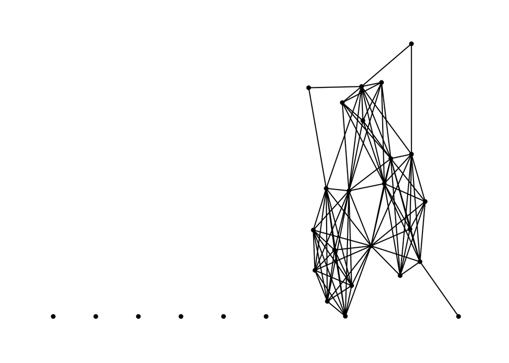

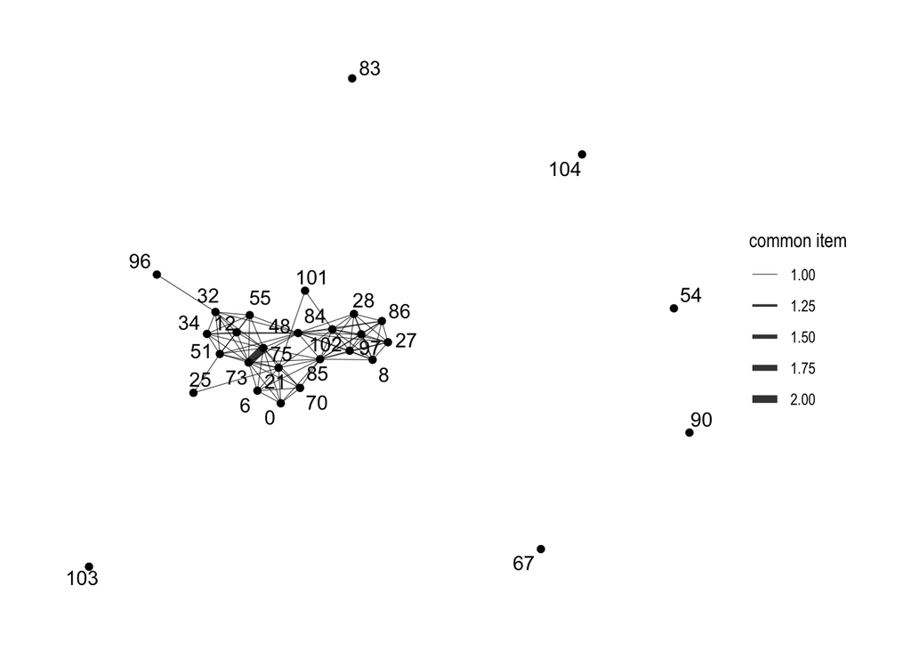

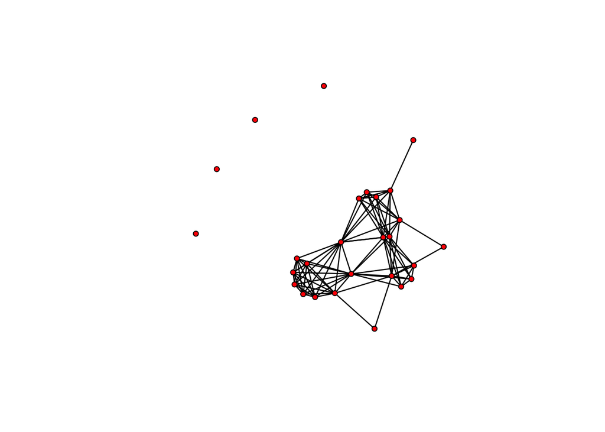

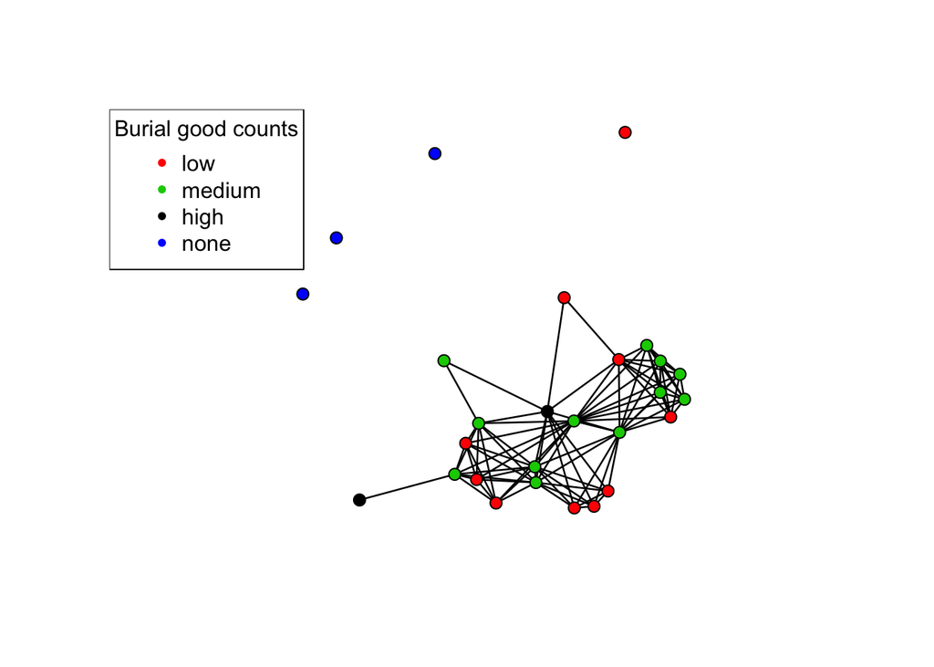

# 4 Results

```
#>       edges     density    triangle
#>  91.0000000   0.2592593 182.0000000
#>           edges gwesp.fixed.0.2 gwdeg.fixed.0.8
#>         91.0000        108.9881         48.1657
#>              edges nodematch.quantity      nodematch.age    gwesp.fixed.0.2
#>            91.0000            42.0000            41.0000           108.9881
#>    gwdeg.fixed.0.8
#>            48.1657
```

Normal distribution 𝜃 ∼ Nd (𝜇prior , Σprior ) is viewed as a suitable prior model for the model parameters of interests in network analysis (Caimo et al., 2017). We specified the prior based on normal distribution that assumes a low density and high transitivity network.

```
#>
#>  Posterior Density Estimate for Model: y ~ edges + nodematch("quantity") + nodematch("age") + gwesp(0.2, fixed = TRUE) + gwdegree(0.8, fixed = TRUE)
#>
#>                                    Mean        SD    Naive SE Time-series SE
#> theta1 (edges)              -4.43501609 1.2193982 0.009640189     0.06694219
#> theta2 (nodematch.quantity)  0.54619420 0.3064932 0.002423041     0.01706078
#> theta3 (nodematch.age)       0.04334645 0.3570066 0.002822385     0.02105387
#> theta4 (gwesp.fixed.0.2)     2.58239458 0.9444714 0.007466702     0.05157408
#> theta5 (gwdeg.fixed.0.8)    -1.75307396 0.6659005 0.005264406     0.03592568
#>
#>                                    2.5%        25%         50%        75%
#> theta1 (edges)              -6.64245156 -5.2489347 -4.48086477 -3.6076056
#> theta2 (nodematch.quantity) -0.09011955  0.3487641  0.54450466  0.7396726
#> theta3 (nodematch.age)      -0.68153434 -0.1776595  0.04455707  0.2725105
#> theta4 (gwesp.fixed.0.2)     0.69976656  1.9335102  2.64810214  3.2189231
#> theta5 (gwdeg.fixed.0.8)    -3.18278333 -2.1917793 -1.74002974 -1.2710747
#>                                  97.5%
#> theta1 (edges)              -1.8900183
#> theta2 (nodematch.quantity)  1.1498766
#> theta3 (nodematch.age)       0.6884431
#> theta4 (gwesp.fixed.0.2)     4.3558771
#> theta5 (gwdeg.fixed.0.8)    -0.5892186
#>
#>  Acceptance rate: 0.14
#>
#>
```

The summary presents the statistics that each θ corresponds to the parameter specified in ERGM previously. In general, positive mean indicates positive correlation, while negative mean indicates negative correlation.

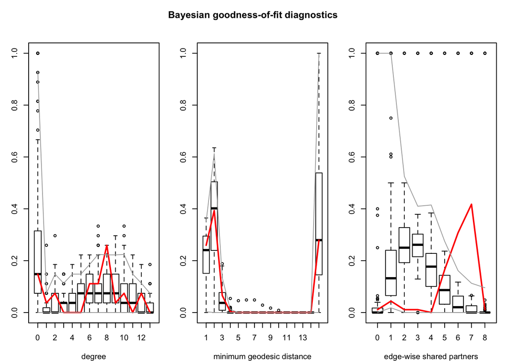

# 5 Discussion

# 6 Conclusion

# 7 Acknowledgements

# 8 References

Amati, V., Mol, A., Shafie, T., Hofman, C., Brandes, U., 2019. A framework for reconstructing archaeological networks using exponential random graph models. Journal of Archaeological Method and Theory 1–28.

Berrocal, M.C., Herrero, E.S., Moret, M.G., González, A.U., Pérez, M.T., Rodrı'guez, S.C., Chevalier, A., Valentin, F., Tsang, C.-h., 2018. A comprised archaeological history of taiwan through the long-term record of heping dao, keelung. International Journal of Historical Archaeology 22, 905–940.

Borao Mateo, J.E., 2009. The spanish experience in Taiwan, 1626-1642 the baroque ending of a renaissance endeavor. Hong Kong University Press, Hong Kong.

Caimo, A., Friel, N., 2014. Bergm: Bayesian exponential random graphs in r. Journal of Statistical Software 61, 1–25.

Caimo, A., Friel, N., 2011. Bayesian inference for exponential random graph models. Social Networks 33, 41–55.

Caimo, A., Lomi, A., 2015. Knowledge sharing in organizations: A bayesian analysis of the role of reciprocity and formal structure. Journal of Management 41, 665–691.

Caimo, A., Pallotti, F., Lomi, A., 2017. Bayesian exponential random graph modelling of interhospital patient referral networks. Statistics in medicine 36, 2902–2920.

Chen, Y.-p., 2007. Qi wu lan yi zhi qiang jiu fa jue bao gao [report on the archaeological excavations at ki-wu-lan site]. Lanyang museum, Yilan, Taiwan.

Cheng, C.-f., 2008. Qi wu lan yi zhi yu she nei yi zhi chu tu bo li zhu de xiang guan yan jiu [studies of glass beads excavated from kivulan and shenei site, Taiwan] (Master’s thesis).

Coward, F., 2013. Grounding the net: Social networks, material culture and geography in the epipalaeolithic and early neolithic of the near east ( 21,000–6,000 cal bce), in: Knappett, C. (Ed.), Network Analysis in Archaeology: New Regional Approaches to Interaction. Oxford University Press, Oxford, pp. 247–280.

Ehrhardt, K.L., 2009. Copper working technologies, contexts of use, and social complexity in the eastern woodlands of native North America. Journal of World Prehistory 22, 213–235.

Freeman, L., 2004. The development of social network analysis. A Study in the Sociology of Science.

Gamble, L.H., Zepeda, I.C., 2002. Social differentiation and exchange among the kumeyaay indians during the historic period in california. Historical Archaeology 71–91.

Hsieh, E., 2012. You pei zang pin de liang hua yan jiu kan qi wu lan yi zhi shang wen hua ceng zao qi nei bu de she hui guan xi [exploring the social relation: A quantitative analysis of burial goods for upper culture layer of kiwulan site].

Hsieh, M.-L., 1995. An ping hu zou yi [some modest remarks on the an-p’ing jug]. Guo li tai wan da xue mei shu shi yan jiu ji kan [Taida Journal of Art History] 2, 75–105.

Hunter, D.R., Handcock, M.S., Butts, C.T., Goodreau, S.M., Morris, M., 2008. Ergm: A package to fit, simulate and diagnose exponential-family models for networks. Journal of statistical software 24, nihpa54860.

Janes, S., 2013. Death and burial in the age of the cypriot city-kingdoms: Social complexity based on the mortuary evidence. Bulletin of the American Schools of Oriental Research 145–168.

Johansen, P.G., Bauer, A.M., 2015. Beyond culture history at maski: Land use, settlement and social differences in neolithic through medieval south India. Archaeological Research in Asia 1, 6–16.

Ketel, C., 2011. Identification of export porcelains from early 17th century voc shipwrecks and the linkage to their cultural identification, in: Core, D. (Ed.), The 2011 Asia-Pacific Regional Conference on Underwater Cultural Heritage Proceedings. Manila, Philippines, pp. 1–14.

Mizoguchi, K., 2013. Evolution of prestige good systems: An application of network analysis to the transformation of communication systems and their media, in: Knappett, C. (Ed.), Network Analysis in Archaeology: New Regional Approaches to Interaction. Oxford University Press, Oxford, pp. 151–180.

Morris, M., Handcock, M.S., Hunter, D.R., 2008. Specification of exponential-family random graph models: Terms and computational aspects. Journal of statistical software 24, 1548.

Nemmers, T., Narayan, A., Banerjee, S., 2019. Bayesian modeling and uncertainty quantification for descriptive social networks. Statistics and its interface 12, 181.

Potgieter, A., April, K., Cooke, R.J., Osunmakinde, I.O., 2008. Temporality in link prediction: Understanding social complexity.

Salvini, A., 2010. Symbolic interactionism and social network analysis: An uncertain encounter. Symbolic Interaction 33, 364–388.

### 8.0.1 Colophon

The current Git commit details are:

```
#> Local:    master /Users/EmilyWang/Desktop/School document/LW-Paper/kwl-burials-2020
#> Remote:   master @ origin (https://github.com/LiYingWang/kwlburials.git)
#> Head:     [bfd20c7] 2020-04-07: add code to the rmd file and edit the method section
```